# Classification of Parkinson’s disease using Jitter Frequency and Speech Measurements

## Introduction

Parkinson’s Disease is a neurological disorder effecting more than 6 million people worldwide that impacts individuals motor skills, speech and cognitive abilities.[1] There are currently no tests that are able to use biomarkers to accurately identify and diagnose Parkinson’s Disease (PD). Therefore, diagnosis of PD is reliant on clinical observation of the symptoms of PD. Relying on the presence of these symptoms prevents early diagnosis, and costs the effected individuals valuable time in getting treatment to slow the progression of the disease. One option to improve the early diagnosis of PD is to use speech data, which had been found to be one of the earliest detectable PD symptoms.[1] Using the biomedical voice measurements data from [2], we will attempt to use various data analytics methods to classify potential PD cases.

## Objectives

- Identify which explanatory variables are most significant to explaining Parkinson’s disease status
- Build a Logistic Regression and a Random Forest Classification model to classify Parkinson’s disease status
- Compare the models to find which is best at classifying Parkinson’s disease status

## Analysis Plan

### Exploratory Data Analysis

Exploring this dataset was accomplished mainly through thorough research of the various features to see what they mean and how they can be used. This gave us a lot of insight into the data as at first we were unsure where to begin with feature selection. We also did basic statistics on the fields to ensure that there weren’t outliers and that the data was clean and complete.

### Data Analytics Methods

After using the feature selection we then split the data into a training and a testing set of data. We did 70% for training and the remaining 30% were used for testing. This meant we ended up with 136 records for training and 59 records for testing.

The machine learning models we considered for this analysis were **Logistic Regression**, **Decision Tree**, **Random Forest**, and **Support Vector Machines**. These models are first trained on the training data and then tested against the testing data after the model has been trained. The results that the model gives are then compared to the expected results (whether someone has Parkinson’s disease) and rate of miscalculation and confusion matrix are then created. The **rate of miscalculation** is created by subtracting the mean of the amount of correct observations from 1. This gives us a percentage of the time the model. To create the **confusion matrix** we use the R built-in **table()** method to create a table of the amount of observations that have Parkinson’s and those that do not for both the testing dataset and the predictions the model gives us.

### Data Summary

The features from the dataset we will be looking at include: MDVP.Fhi(Hz), MDVP:Flo(Hz), NHR, RPDE, DFA, spread2 and status.

**MDVP.Fhi(Hz)** is the maximum vocal fundamental frequency in Hertz and **MDVP:Flo(Hz)** is the minimum vocal fundamental frequency in Hertz. This is calculated using the **Kay Pentax Multidimensional Voice Program (MDVP)**. The fundamental frequency is the lowest frequency of vibration in a sound wave and is what determines the pitch of the sound. [5]

**NHR** stands for Noise-to-Harmonic Ratio, and it is calculated by dividing the energy of the tonal components in the voice by the energy of the noise components. It is a useful measure for assessing vocal health and can be used to identify changes in vocal quality that may be associated with conditions such as vocal cord nodules, vocal cord paralysis, and Parkinson’s disease. [4]

**RPDE** stands for Rescaled Phase Dependent Entropy. It is a measure of the complexity of a time series that is based on the distribution of the phases of the constituent frequencies. It is a useful measures for assessing the complexity of a time series. They can be used to identify changes in the complexity of a time series that may be associated with changes in the underlying system. For example, RPDE has been used to study the changes in the complexity of the voice that are associated with Parkinson’s disease. [3]

**DFA** stands forDetrended fluctuation analysis (DFA) is a measure of the similarity of noise in speech signals. It is used to identify voice disorders by measuring the scaling exponent of the noise. A higher scaling exponent indicates a more disordered signal, which is associated with voice disorders. [3]

**spread2** is a measure of the unevenness of the distribution of fundamental frequencies in a voice signal. It is calculated as the standard deviation of the fundamental frequencies in the signal. A higher spread2 value indicates a more variable fundamental frequency, which is associated with voice disorders. [6]

**status** is a binary attribute that sua whether the person has Parkinson’s (1) or does not have Parkinson’s (0).

## References

- *[1]*: Zhang, H.-H., Yang, L., Liu, Y., Wang, P., Yin, J., Li, Y., Qiu, M., Zhu, X., & Yan, F. (2016, November 16). Classification of parkinson’s disease utilizing multi-edit nearest-neighbor and ensemble learning algorithms with speech samples. PubMed Central. Retrieved April 30, 2023, from https://www.ncbi.nlm.nih.gov/pmc/articles/PMC5112697/
- *[2]*: ‘Exploiting Nonlinear Recurrence and Fractal Scaling Properties for Voice Disorder Detection’, Little MA, McSharry PE, Roberts SJ, Costello DAE, Moroz IM. BioMedical Engineering OnLine 2007, 6:23 (26 June 2007) https://archive.ics.uci.edu/ml/machine-learning-databases/parkinsons/
- *[3]*: Max A. Little, Patrick E. McSharry, Eric J. Hunter, Lorraine O. Ramig (2008), ‘Suitability of dysphonia measurements for telemonitoring of Parkinson’s disease’, IEEE Transactions on Biomedical Engineering (to appear).
- *[4]*: Little, Max A. (2019). “A Tutorial on Voice Analysis in R”. RPubs. Retrieved from https://rstudio-pubs-static.s3.amazonaws.com/197257_4ecb7314bc1f4619b59ab44a1374ce7f.html
- *[5]*: Wu Y, Chen P, Yao Y, Ye X, Xiao Y, Liao L, Wu M, Chen J. Dysphonic Voice Pattern Analysis of Patients in Parkinson’s Disease Using Minimum Interclass Probability Risk Feature Selection and Bagging Ensemble Learning Methods. Comput Math Methods Med. 2017;2017:4201984. doi: 10.1155/2017/4201984. Epub 2017 May 3. PMID: 28553366; PMCID: PMC5434464.
- *[6]*: Vance, Matt. (2019). “A Tutorial on Voice Analysis in R”. RPubs. Retrieved from https://rpubs.com/VanceMatt/197257

## Appendix

```r
library(tidyverse)
library(ggplot2)
library(MASS)
library(tree)
library(randomForest)
library(psych)
library(caret)
library(kernlab)
library(e1071)
```

```r
parkinsons_data <- read.csv('parkinsons.data')


parkinsons_data_less_fields <- subset(parkinsons_data, select = c(name, MDVP.Fo.Hz., MDVP.Jitter..., Jitter.DDP, MDVP.RAP, MDVP.PPQ, MDVP.Shimmer,
                                                               MDVP.APQ, Shimmer.DDA, HNR, status))

#ddp is the measure of the average absolute difference between jitter cycles
#Relative amplitude perturbation (RAP) is a measure of the variability of the amplitude of a voice signal
#Five-point period perturbation quotient (PPQ) is a measure of the variability of the fundamental frequency (F0) of a voice signal
#rap and ppq are used to objectively measure vocal quality of voice
#shimmer is a measure of the variability of the amplitude of a voice signal.
#MDVP 11-point amplitude perturbation quotient (APQ) is a measure of the variability of the amplitude of a voice signal. A high APQ11 value indicates that the amplitude of the voice signal is variable, which can be a sign of vocal pathology. For example, people with vocal nodules or polyps often have a high APQ11 value.
#dda of shimmer is the measure of the average absolute differences between the amplitudes of consecutive periods
#hnr is the ration of harmonics to noise
#status whether or not they have Parkinsons disese

colnames(parkinsons_data_less_fields) <- c("id", "avg_vocal_freq", "percent_measure_of_jitter", "ddp_measure_of_jitter",
                                           "rap_measure_of_vocals", "ppq_measure_of_vocals", "measure_of_shimmer",
                                           "apq_measure_of_shimmer", "dda_measure_of_shimmer", "hnr", "status")
head(parkinsons_data_less_fields)
```

```
##               id avg_vocal_freq percent_measure_of_jitter ddp_measure_of_jitter
## 1 phon_R01_S01_1        119.992                   0.00784               0.01109
## 2 phon_R01_S01_2        122.400                   0.00968               0.01394
## 3 phon_R01_S01_3        116.682                   0.01050               0.01633
## 4 phon_R01_S01_4        116.676                   0.00997               0.01505
## 5 phon_R01_S01_5        116.014                   0.01284               0.01966
## 6 phon_R01_S01_6        120.552                   0.00968               0.01388
##   rap_measure_of_vocals ppq_measure_of_vocals measure_of_shimmer
## 1               0.00370               0.00554            0.04374
## 2               0.00465               0.00696            0.06134
## 3               0.00544               0.00781            0.05233
## 4               0.00502               0.00698            0.05492
## 5               0.00655               0.00908            0.06425
## 6               0.00463               0.00750            0.04701
##   apq_measure_of_shimmer dda_measure_of_shimmer    hnr status
## 1                0.02971                0.06545 21.033      1
## 2                0.04368                0.09403 19.085      1
## 3                0.03590                0.08270 20.651      1
## 4                0.03772                0.08771 20.644      1
## 5                0.04465                0.10470 19.649      1
## 6                0.03243                0.06985 21.378      1
```

```r
describe(parkinsons_data_less_fields)
```

```
##                           vars   n   mean    sd median trimmed   mad   min
## id*                          1 195  98.00 56.44  98.00   98.00 72.65  1.00
## avg_vocal_freq               2 195 154.23 41.39 148.79  150.80 47.13 88.33
## percent_measure_of_jitter    3 195   0.01  0.00   0.00    0.01  0.00  0.00
## ddp_measure_of_jitter        4 195   0.01  0.01   0.01    0.01  0.00  0.00
## rap_measure_of_vocals        5 195   0.00  0.00   0.00    0.00  0.00  0.00
## ppq_measure_of_vocals        6 195   0.00  0.00   0.00    0.00  0.00  0.00
## measure_of_shimmer           7 195   0.03  0.02   0.02    0.03  0.01  0.01
## apq_measure_of_shimmer       8 195   0.02  0.02   0.02    0.02  0.01  0.01
## dda_measure_of_shimmer       9 195   0.05  0.03   0.04    0.04  0.02  0.01
## hnr                         10 195  21.89  4.43  22.09   22.17  4.37  8.44
## status                      11 195   0.75  0.43   1.00    0.82  0.00  0.00
##                              max  range  skew kurtosis   se
## id*                       195.00 194.00  0.00    -1.22 4.04
## avg_vocal_freq            260.10 171.77  0.58    -0.67 2.96
## percent_measure_of_jitter   0.03   0.03  3.04    11.54 0.00
## ddp_measure_of_jitter       0.06   0.06  3.31    13.66 0.00
## rap_measure_of_vocals       0.02   0.02  3.31    13.65 0.00
## ppq_measure_of_vocals       0.02   0.02  3.03    11.48 0.00
## measure_of_shimmer          0.12   0.11  1.64     3.06 0.00
## apq_measure_of_shimmer      0.14   0.13  2.58    10.71 0.00
## dda_measure_of_shimmer      0.17   0.16  1.56     2.56 0.00
## hnr                        33.05  24.61 -0.51     0.53 0.32
## status                      1.00   1.00 -1.17    -0.64 0.03
```

```r
set.seed(123)

train_index <- sample(nrow(parkinsons_data_less_fields), nrow(parkinsons_data_less_fields) * 0.7)

predict_parkinsons.train <- parkinsons_data_less_fields[train_index, ]
head(predict_parkinsons.train)
```

```
##                 id avg_vocal_freq percent_measure_of_jitter
## 159 phon_R01_S37_6        126.144                   0.00975
## 179 phon_R01_S44_2        148.790                   0.00309
## 14  phon_R01_S04_2        139.173                   0.00390
## 170 phon_R01_S42_5        240.301                   0.00517
## 50  phon_R01_S13_2        122.964                   0.00428
## 118 phon_R01_S27_3        170.756                   0.00555
##     ddp_measure_of_jitter rap_measure_of_vocals ppq_measure_of_vocals
## 159               0.01778               0.00593               0.00454
## 179               0.00456               0.00152               0.00186
## 14                0.00496               0.00165               0.00208
## 170               0.00949               0.00316               0.00283
## 50                0.00373               0.00124               0.00155
## 118               0.00731               0.00244               0.00261
##     measure_of_shimmer apq_measure_of_shimmer dda_measure_of_shimmer    hnr
## 159            0.02852                0.02157                0.04499 21.534
## 179            0.01574                0.01309                0.02518 24.412
## 14             0.01642                0.01797                0.02184 24.889
## 170            0.02018                0.01344                0.03529 21.020
## 50             0.01681                0.01400                0.02789 24.971
## 118            0.01725                0.01652                0.02270 25.690
##     status
## 159      1
## 179      1
## 14       1
## 170      0
## 50       0
## 118      1
```

```r
nrow(predict_parkinsons.train)
```

```
## [1] 136
```

```r
predict_parkinsons.test <- parkinsons_data_less_fields[-train_index, ]
head(predict_parkinsons.test)
```

```
##                id avg_vocal_freq percent_measure_of_jitter
## 1  phon_R01_S01_1        119.992                   0.00784
## 2  phon_R01_S01_2        122.400                   0.00968
## 3  phon_R01_S01_3        116.682                   0.01050
## 10 phon_R01_S02_4         95.056                   0.00532
## 11 phon_R01_S02_5         88.333                   0.00505
## 15 phon_R01_S04_3        152.845                   0.00294
##    ddp_measure_of_jitter rap_measure_of_vocals ppq_measure_of_vocals
## 1                0.01109               0.00370               0.00554
## 2                0.01394               0.00465               0.00696
## 3                0.01633               0.00544               0.00781
## 10               0.00803               0.00268               0.00332
## 11               0.00763               0.00254               0.00330
## 15               0.00364               0.00121               0.00149
##    measure_of_shimmer apq_measure_of_shimmer dda_measure_of_shimmer    hnr
## 1             0.04374                0.02971                0.06545 21.033
## 2             0.06134                0.04368                0.09403 19.085
## 3             0.05233                0.03590                0.08270 20.651
## 10            0.02838                0.02444                0.04324 21.862
## 11            0.02143                0.01892                0.03237 21.118
## 15            0.01828                0.01246                0.03191 24.922
##    status
## 1       1
## 2       1
## 3       1
## 10      1
## 11      1
## 15      1
```

```r
nrow(predict_parkinsons.test)
```

```
## [1] 59
```

```r
# lm.parkinsons.tr <- lm(status ~ avg_vocal_freq + percent_measure_of_jitter + ddp_measure_of_jitter +
#                                 rap_measure_of_vocals + ppq_measure_of_vocals + measure_of_shimmer +
#                                 apq_measure_of_shimmer + dda_measure_of_shimmer + hnr, data = predict_parkinsons.train)
# lm_test_error <- mean((predict_parkinsons.test$status - predict(lm.parkinsons.tr, predict_parkinsons.test))^2)
# paste("The value of the logistic test error is:", lm_test_error)

# logistic regression
glm.parkinsons.tr <- glm(status ~ avg_vocal_freq + percent_measure_of_jitter + ddp_measure_of_jitter +
                         rap_measure_of_vocals + ppq_measure_of_vocals + measure_of_shimmer +
                         apq_measure_of_shimmer + dda_measure_of_shimmer + hnr, family = binomial ,data = predict_parkinsons.train)
glm.parkinsons.tr
```

```
##
## Call:  glm(formula = status ~ avg_vocal_freq + percent_measure_of_jitter +
##     ddp_measure_of_jitter + rap_measure_of_vocals + ppq_measure_of_vocals +
##     measure_of_shimmer + apq_measure_of_shimmer + dda_measure_of_shimmer +
##     hnr, family = binomial, data = predict_parkinsons.train)
##
## Coefficients:
##               (Intercept)             avg_vocal_freq
##                -4.340e+00                 -1.203e-02
## percent_measure_of_jitter      ddp_measure_of_jitter
##                -1.097e+03                 -7.509e+03
##     rap_measure_of_vocals      ppq_measure_of_vocals
##                 2.559e+04                 -6.742e+02
##        measure_of_shimmer     apq_measure_of_shimmer
##                -1.970e+02                  9.061e+02
##    dda_measure_of_shimmer                        hnr
##                -1.768e+02                  8.994e-02
##
## Degrees of Freedom: 135 Total (i.e. Null);  126 Residual
## Null Deviance:       155.1
## Residual Deviance: 87.11     AIC: 107.1
```

```r
# glm_test_error <- mean((predict_parkinsons.test$status - predict(glm.parkinsons.tr, predict_parkinsons.test))^2)
# paste("The value of the logistic test error is:", glm_test_error)

glm.probs <- predict(glm.parkinsons.tr,predict_parkinsons.test, type = 'response' )
glm.pred=rep(0,nrow(predict_parkinsons.test))
glm.pred[glm.probs >.5]=1

table(glm.pred, predict_parkinsons.test$status)
```

```
##
## glm.pred  0  1
##        0  9 10
##        1  4 36
```

```r
# rate of misclassification
glm_error_rate<- (1-mean(glm.pred==predict_parkinsons.test$status))
paste("The logistic missclasification rate is:", glm_error_rate)
```

```
## [1] "The logistic missclasification rate is: 0.23728813559322"
```

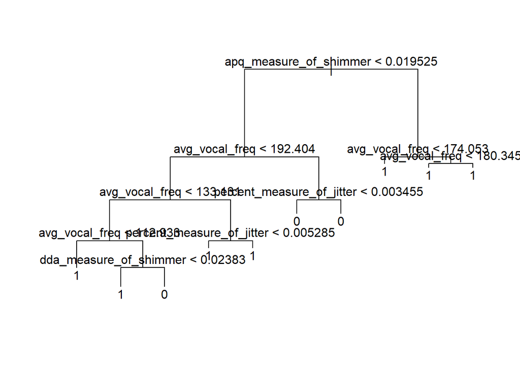

```r
tree.parkinsons.tr <- tree(as.factor(status) ~ avg_vocal_freq + percent_measure_of_jitter + ddp_measure_of_jitter +
                            rap_measure_of_vocals + ppq_measure_of_vocals + measure_of_shimmer +
                            apq_measure_of_shimmer + dda_measure_of_shimmer + hnr, data = predict_parkinsons.train)
plot(tree.parkinsons.tr)
text(tree.parkinsons.tr, pretty = 0)
```

```r
# yhat <- predict(tree.parkinsons.tr, newdata = predict_parkinsons.test)
# tree_test_error <- mean((yhat - predict_parkinsons.test$status)^2)
# paste("The error from the tree regression is: ", tree_test_error)
# paste("This tree model is less accurate than the logistic model by:", abs(lm_test_error - tree_test_error))

tree.pred <- predict(tree.parkinsons.tr,predict_parkinsons.test, type = 'class')
table(tree.pred,predict_parkinsons.test$status)
```

```
##
## tree.pred  0  1
##         0 10  9
##         1  3 37
```

```r
# rate of misclassification
tree_error_rate<- (1-mean(tree.pred==predict_parkinsons.test$status))
paste("The regression tree  missclasification rate is:", tree_error_rate)
```

```
## [1] "The regression tree  missclasification rate is: 0.203389830508475"
```

```r
paste("The regression tree  missclasification rate is lower than the logistic model missclasification rate by:", abs(glm_error_rate-tree_error_rate))
```

```
## [1] "The regression tree  missclasification rate is lower than the logistic model missclasification rate by: 0.0338983050847458"
```

```r
rf.parkinsons <- randomForest(as.factor(status) ~ avg_vocal_freq + percent_measure_of_jitter + ddp_measure_of_jitter +
                                rap_measure_of_vocals + ppq_measure_of_vocals + measure_of_shimmer +
                                apq_measure_of_shimmer + dda_measure_of_shimmer + hnr, data = predict_parkinsons.train, mtry=3, importance=TRUE)
rf.parkinsons
```

```
##
## Call:
##  randomForest(formula = as.factor(status) ~ avg_vocal_freq + percent_measure_of_jitter +      ddp_measure_of_jitter + rap_measure_of_vocals + ppq_measure_of_vocals +      measure_of_shimmer + apq_measure_of_shimmer + dda_measure_of_shimmer +      hnr, data = predict_parkinsons.train, mtry = 3, im…
##                Type of random forest: classification
##                      Number of trees: 500
## No. of variables tried at each split: 3
##
##         OOB estimate of  error rate: 13.97%
## Confusion matrix:
##    0  1 class.error
## 0 22 13  0.37142857
## 1  6 95  0.05940594
```

```r
# yhat.rf.parkinsons <- predict(rf.parkinsons, newdata = predict_parkinsons.test)
# forest_test_error <- mean((yhat.rf.parkinsons - predict_parkinsons.test$status)^2)
# paste("The error from the forest regression is: ", forest_test_error)
# paste("This new model is more accurate than the tree model by:", tree_test_error - forest_test_error)
# paste("This new model is more accurate than the regreession model by:", lm_test_error - forest_test_error)
paste("The random forest tree  missclasification rate is:", rf.parkinsons$err.rate[500,1])
```

```
## [1] "The random forest tree  missclasification rate is: 0.139705882352941"
```

```r
paste("The random forest tree  missclasification rate is lower than the logistic model missclasification rate by:", glm_error_rate-(rf.parkinsons$err.rate[500,1]))
```

```
## [1] "The random forest tree  missclasification rate is lower than the logistic model missclasification rate by: 0.0975822532402792"
```

```r
paste("The random forest tree  missclasification rate is lower than the regression tree missclasification rate by:", tree_error_rate-(rf.parkinsons$err.rate[500,1]))
```

```
## [1] "The random forest tree  missclasification rate is lower than the regression tree missclasification rate by: 0.0636839481555334"
```

## R Codes using correlation to select features

```r
#library(caret)
#################################################### using selected features
test_Park <- parkinsons_data %>%
  mutate(parkinson = status)%>%
  dplyr::select(-c(name,status))

######## find highly correlated features
cor_matrix2 <-cor(test_Park[,1:22])
findCorrelation(cor_matrix2, cutoff=0.5)
```

```
##  [1] 10  9  7  4 13 14 11 12  5  6  8 22 16 19 21  1
```

```r
#keep only non-highly correlated features
#MDVP.Fhi.Hz , MDVP.Flo.Hz.,  NHR , RPDE, DFA , spread2, parkinson(status)
park_subset<-test_Park[,c(2,3,15,17,18,20,23)]

sub_train <- sample(nrow(park_subset), nrow(park_subset) * 0.7)

predict_sub_parkinsons.train <- park_subset[sub_train, ]


predict_sub_parkinsons.test <- park_subset[-sub_train, ]



# glm
glm.park2 <- glm(parkinson ~ ., family = binomial ,data = predict_sub_parkinsons.train)
glm.park2
```

```
##
## Call:  glm(formula = parkinson ~ ., family = binomial, data = predict_sub_parkinsons.train)
##
## Coefficients:
##  (Intercept)  MDVP.Fhi.Hz.  MDVP.Flo.Hz.           NHR          RPDE
##    -4.807569     -0.004289     -0.012758     24.696603     -0.821029
##          DFA       spread2
##     7.887773     14.439311
##
## Degrees of Freedom: 135 Total (i.e. Null);  129 Residual
## Null Deviance:       143.5
## Residual Deviance: 96.85     AIC: 110.9
```

```r
glm.probs2 <- predict(glm.park2,predict_sub_parkinsons.test, type = 'response' )
glm.pred2=rep(0,nrow(predict_sub_parkinsons.test))
glm.pred2[glm.probs2 >.5]=1

table(glm.pred2, predict_sub_parkinsons.test$parkinson)
```

```
##
## glm.pred2  0  1
##         0  9  0
##         1  9 41
```

```r
# rate of misclassification

sub_glm_error_rate<- 1-mean(glm.pred2==predict_sub_parkinsons.test$parkinson)
paste("The logistic missclasification rate is:", sub_glm_error_rate)
```

```
## [1] "The logistic missclasification rate is: 0.152542372881356"
```

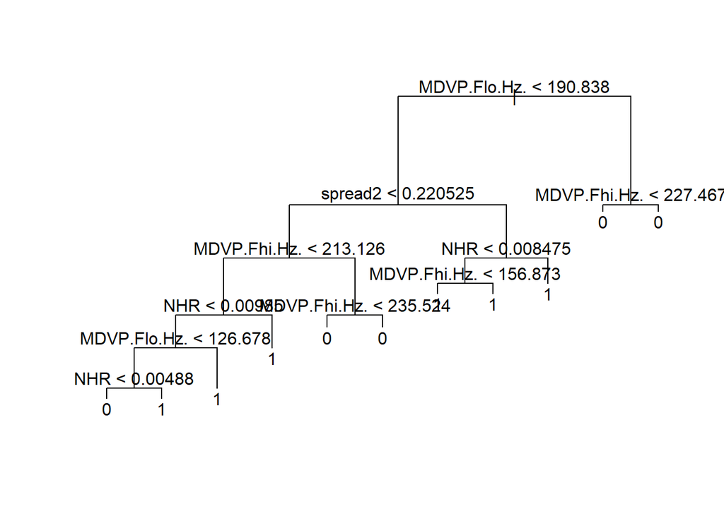

```r
# regression tree

sub_park_tree <- tree(as.factor(parkinson) ~., data = predict_sub_parkinsons.train)
plot(sub_park_tree)
text(sub_park_tree, pretty = 0)
```

```r
sub_tree.pred <- predict(sub_park_tree,predict_sub_parkinsons.test, type = 'class')
table(sub_tree.pred,predict_sub_parkinsons.test$parkinson)
```

```
##
## sub_tree.pred  0  1
##             0 13  4
##             1  5 37
```

```r
# rate of misclassification
sub_tree_error_rate<- (1-mean(sub_tree.pred==predict_sub_parkinsons.test$parkinson))
paste("The regression tree  missclasification rate is:", sub_tree_error_rate)
```

```
## [1] "The regression tree  missclasification rate is: 0.152542372881356"
```

```r
## RF tree

sub_rf.parkinsons <- randomForest(as.factor(parkinson) ~ ., data = predict_sub_parkinsons.train, mtry=3, importance=TRUE)
sub_rf.parkinsons
```

```
##
## Call:
##  randomForest(formula = as.factor(parkinson) ~ ., data = predict_sub_parkinsons.train,      mtry = 3, importance = TRUE)
##                Type of random forest: classification
##                      Number of trees: 500
## No. of variables tried at each split: 3
##
##         OOB estimate of  error rate: 8.82%
## Confusion matrix:
##    0   1 class.error
## 0 21   9  0.30000000
## 1  3 103  0.02830189
```

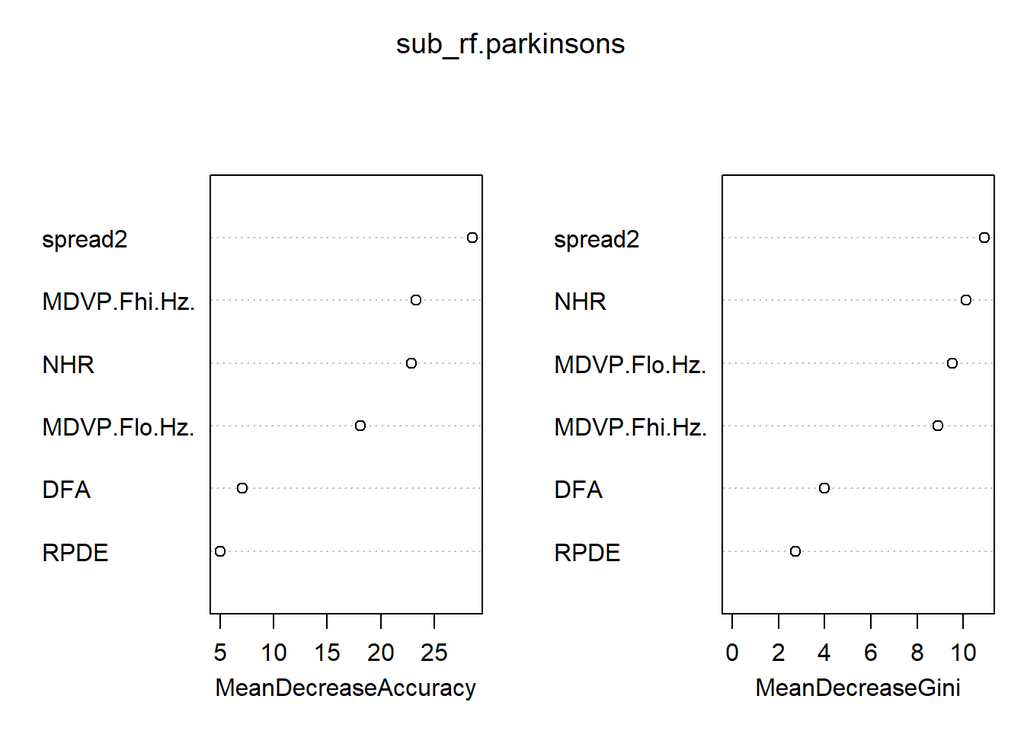

```r
varImpPlot(sub_rf.parkinsons)
```

```r
paste("The random forest tree  missclasification rate is:", sub_rf.parkinsons$err.rate[500,1])
```

```
## [1] "The random forest tree  missclasification rate is: 0.0882352941176471"
```

```r
paste("The random forest tree  missclasification rate is lower than the logistic model missclasification rate by:", sub_glm_error_rate-(sub_rf.parkinsons$err.rate[500,1]))
```

```
## [1] "The random forest tree  missclasification rate is lower than the logistic model missclasification rate by: 0.0643070787637089"
```

```r
paste("The random forest tree  missclasification rate is lower than the regression tree missclasification rate by:", sub_tree_error_rate-(sub_rf.parkinsons$err.rate[500,1]))
```

```
## [1] "The random forest tree  missclasification rate is lower than the regression tree missclasification rate by: 0.0643070787637089"
```

```r
### SVM
sub_tune.out <- tune(svm, as.factor(parkinson) ~., data=predict_sub_parkinsons.train, kernel ="radial",
                 ranges =list(cost=c(0.1 ,1 ,10 ,100 ,1000),
                              gamma=c(0.5,1,2,3,4) ))
summary(sub_tune.out)
```

```
##
## Parameter tuning of 'svm':
##
## - sampling method: 10-fold cross validation
##
## - best parameters:
##  cost gamma
##     1     1
##
## - best performance: 0.1192308
##
## - Detailed performance results:
##     cost gamma     error dispersion
## 1  1e-01   0.5 0.2219780 0.08924508
## 2  1e+00   0.5 0.1637363 0.10236113
## 3  1e+01   0.5 0.1263736 0.10014815
## 4  1e+02   0.5 0.1263736 0.11589225
## 5  1e+03   0.5 0.1263736 0.11589225
## 6  1e-01   1.0 0.2219780 0.08924508
## 7  1e+00   1.0 0.1192308 0.10227097
## 8  1e+01   1.0 0.1340659 0.13085180
## 9  1e+02   1.0 0.1340659 0.13085180
## 10 1e+03   1.0 0.1340659 0.13085180
## 11 1e-01   2.0 0.2219780 0.08924508
## 12 1e+00   2.0 0.1565934 0.08587576
## 13 1e+01   2.0 0.1417582 0.12103996
## 14 1e+02   2.0 0.1417582 0.12103996
## 15 1e+03   2.0 0.1417582 0.12103996
## 16 1e-01   3.0 0.2219780 0.08924508
## 17 1e+00   3.0 0.1631868 0.07809374
## 18 1e+01   3.0 0.1489011 0.08184375
## 19 1e+02   3.0 0.1489011 0.08184375
## 20 1e+03   3.0 0.1489011 0.08184375
## 21 1e-01   4.0 0.2219780 0.08924508
## 22 1e+00   4.0 0.1631868 0.07809374
## 23 1e+01   4.0 0.1560440 0.08325581
## 24 1e+02   4.0 0.1560440 0.08325581
## 25 1e+03   4.0 0.1560440 0.08325581
```

```r
svm.parkinsons_sub <- svm(as.factor(parkinson) ~ .,
                      data = predict_sub_parkinsons.train,
                      kernel = "radial",
                      gamma = 0.5,
                      cost = 100)

svm.parkinsons.predictions_sub <- predict(svm.parkinsons_sub, predict_sub_parkinsons.test)
summary(svm.parkinsons.predictions_sub)
```

```
##  0  1
## 16 43
```

```r
table(predict_sub_parkinsons.test$parkinson, svm.parkinsons.predictions_sub)
```

```
##    svm.parkinsons.predictions_sub
##      0  1
##   0 14  4
##   1  2 39
```

```r
svm_error_rate<- (1-mean(svm.parkinsons.predictions_sub==predict_sub_parkinsons.test$parkinson))
paste("The svm  missclasification rate is:", svm_error_rate)
```

```
## [1] "The svm  missclasification rate is: 0.101694915254237"
```

```r
paste("The svm  missclasification rate is lower than the logistic model missclasification rate by:", sub_glm_error_rate-svm_error_rate)
```

```
## [1] "The svm  missclasification rate is lower than the logistic model missclasification rate by: 0.0508474576271187"
```

```r
paste("The svm  missclasification rate is lower than the regression tree missclasification rate by:", sub_tree_error_rate-svm_error_rate)
```

```
## [1] "The svm  missclasification rate is lower than the regression tree missclasification rate by: 0.0508474576271187"
```

```r
paste("The svm  missclasification rate is lower than the random forest tree missclasification rate by:", (sub_rf.parkinsons$err.rate[500,1])-svm_error_rate)
```

```
## [1] "The svm  missclasification rate is lower than the random forest tree missclasification rate by: -0.0134596211365902"
```